# Classification of Irises using Gaussian Naive Bayes

**Naive Bayes** is based on calculating the prior probability for the given class labels. This is followed by computing the posterior probability or likelihood for each feature or attribute with respect to each class.  
Because Iris Datasets are continuous variables, we use **GaussianNB** to calculate the Gaussian or continuous probability for each feature in the dataset by calculating the mean and variance of each feature in each class. Then, when we have given features for an instance and want to calculate its predicted class, the GaussianNB model calculates the posterior probabilities for each feature given each class and then a comparison of these class probabilities is performed (3 classes give 3 probabilities).

## The Iris Dataset

This data sets consists of 3 different types of irises’ (Setosa, Versicolour, and Virginica) petal and sepal length, stored in a 150x4 numpy.ndarray.

The rows being the samples and the columns being: Sepal Length, Sepal Width, Petal Length and Petal Width.

## Installing the Dependencies

```python
!pip install -r requirements.txt
```

## Import the Necessary Modules

```python
import pandas as pd
import matplotlib.pyplot as plt
import joblib
```

## Load the Iris Dataset

```python
from sklearn import datasets
iris = datasets.load_iris()
dir(iris)
```

```
['DESCR',
 'data',
 'data_module',
 'feature_names',
 'filename',
 'frame',
 'target',
 'target_names']
```

## Exploring the Iris Dataset

```python
iris.feature_names
```

```
['sepal length (cm)',
 'sepal width (cm)',
 'petal length (cm)',
 'petal width (cm)']
```

```python
iris.frame
```

```python
iris.target.shape
```

```
(150,)
```

```python
iris.target_names
```

```
array(['setosa', 'versicolor', 'virginica'], dtype='<U10')
```

```python
iris_df = pd.DataFrame(data=iris.data, columns= iris.feature_names)
iris_df.head()
```

|  | sepal length (cm) | sepal width (cm) | petal length (cm) | petal width (cm) |
| --- | --- | --- | --- | --- |
| 0 | 5.1 | 3.5 | 1.4 | 0.2 |
| 1 | 4.9 | 3.0 | 1.4 | 0.2 |
| 2 | 4.7 | 3.2 | 1.3 | 0.2 |
| 3 | 4.6 | 3.1 | 1.5 | 0.2 |
| 4 | 5.0 | 3.6 | 1.4 | 0.2 |

## Visulaising the Dataset

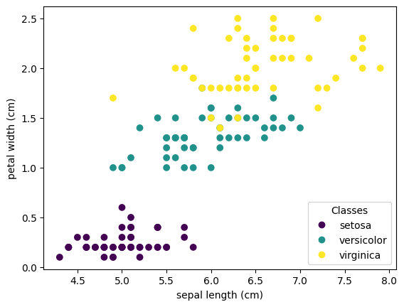

```python
# we visualize the dataset by plotting a scatter plot between the sepal length and petal width
_, ax = plt.subplots()
scatter = ax.scatter(iris.data[:, 0], iris.data[:, 3], c=iris.target)
ax.set(xlabel=iris.feature_names[0], ylabel=iris.feature_names[3])
_ = ax.legend(
    scatter.legend_elements()[0], iris.target_names, loc="lower right", title="Classes"
)
```

## Extracting features and labels from the dataset

```python
# we define an array X that has the features data from all rows and columns
X = iris.data[: , :]
X.shape
```

```
(150, 4)
```

```python
X
```

[output not shown]

[output cut: 95 more lines]

```
       [7.7, 3. , 6.1, 2.3],
       [6.3, 3.4, 5.6, 2.4],
       [6.4, 3.1, 5.5, 1.8],
       [6. , 3. , 4.8, 1.8],
       [6.9, 3.1, 5.4, 2.1],
       [6.7, 3.1, 5.6, 2.4],
       [6.9, 3.1, 5.1, 2.3],
       [5.8, 2.7, 5.1, 1.9],
       [6.8, 3.2, 5.9, 2.3],
       [6.7, 3.3, 5.7, 2.5],
       [6.7, 3. , 5.2, 2.3],
       [6.3, 2.5, 5. , 1.9],
       [6.5, 3. , 5.2, 2. ],
       [6.2, 3.4, 5.4, 2.3],
       [5.9, 3. , 5.1, 1.8]])
```

```python
# we define an array Y that has the labels that correspond to each feature array
y = iris.target
y.shape
```

```
(150,)
```

## Split the Dataset into TestDataset(25%), Used for Evaluation, and TrainsDataset

```python
from sklearn.model_selection import train_test_split
X_train, X_test, y_train, y_test = train_test_split(X, y, test_size=0.25, random_state=42)
```

```python
print(X_train.shape, y_train.shape, X_test.shape, y_test.shape)
```

```
(112, 4) (112,) (38, 4) (38,)
```

## Fit the Data on the Model to Train:

```python
# we will now import the Gaussian NB and fit it to find the Gaussian probabilites of each feature with respect to the target label(class)
from sklearn.naive_bayes import GaussianNB
# We establish a classifier object
clf = GaussianNB()
# fit the classifier object on the features and classes(targets) to calculate the gaussian probalbility of each feature with respect to each class
clf.fit(X_train, y_train)
```

```
GaussianNB()
```

## Exploring model attributes

```python
#count of samples(rows) of each class in the training data
# The total training data is 112, so we have 35 'setosa', 39'versicolor', '38 virginica'
clf.class_count_
```

```
array([35., 39., 38.])
```

```python
# prior probability of each class
clf.class_prior_
```

```
array([0.3125    , 0.34821429, 0.33928571])
```

```python
# what are the class labels?
clf.classes_
```

```
array([0, 1, 2])
```

```python
#absolute additive value to variances
clf.epsilon_
```

```
np.float64(2.9844132653061226e-09)
```

```python
# Number of features seen during fit
clf.n_features_in_
```

```
4
```

```python
# variance of each feature per class
clf.var_
```

```
array([[0.11056327, 0.14546939, 0.0304    , 0.01162449],
       [0.27906641, 0.09737015, 0.23495069, 0.04232742],
       [0.42607341, 0.09587258, 0.28593491, 0.08394045]])
```

```python
# Mean of each feature per class
clf.theta_
```

```
array([[4.99714286, 3.42857143, 1.46      , 0.24571429],
       [5.88717949, 2.75128205, 4.23076923, 1.31538462],
       [6.53947368, 2.97894737, 5.53421053, 2.00263158]])
```

```python
clf.get_params()
```

```
{'priors': None, 'var_smoothing': 1e-09}
```

## Use the Classifier to predict test classes

```python
# we use the classifier to predict the targets or classes of the test data(X_test)
y_pred = clf.predict(X_test)
y_pred
```

```
array([1, 0, 2, 1, 1, 0, 1, 2, 1, 1, 2, 0, 0, 0, 0, 1, 2, 1, 1, 2, 0, 2,
       0, 2, 2, 2, 2, 2, 0, 0, 0, 0, 1, 0, 0, 2, 1, 0])
```

## Evaluating the classifier performance

```python
# We evaluate the accuracy of the model predictions
from sklearn.metrics import confusion_matrix
cm = confusion_matrix(y_test, y_pred)
print(cm)
```

```
[[15  0  0]
 [ 0 11  0]
 [ 0  0 12]]
```

#### From the above confusion matrix we see that the model correctly classified all the test data to their actual classes.

#### From the diagonal elements in the cm, we see that 15 instances were classified as class 0, 11 instances were classified as class 1, 12 instances were classified as class 2

```python
# To further evaluate the classifier
accuracy = clf.score(X, y)
print(accuracy)
```

```
0.96
```

```python
# Another way to evaluate the classifier is by comparing between the y_test and y_pred and count the number of mismatches between the 2 arrays
n_mismatches = (y_test != y_pred).sum()
print(f"There is {n_mismatches} instances out of {len(y_test)} that are misclassified by the classifier,\n which makes the classifier accuracy equal to {(len(y_test) - n_mismatches)/len(y_test):.2f}")
```

```
There is 0 instances out of 38 that are misclassified by the classifier,
 which makes the classifier accuracy equal to 1.00
```

## Saving the model

```python
joblib.dump(clf, 'iris_NB_classifier.pkl')
```

```
['iris_NB_classifier.pkl']
```

## How to Use the Classifier

```python
# Load the model from the file
model = joblib.load('iris_NB_classifier.pkl')

# Define new petal and sepal measurements
new_sample = [[5.1, 3.5, 1.4, 0.2]]

# Make a prediction using the loaded model
predicted_class = model.predict(new_sample)
print(f"The predicted class is {predicted_class}")

# Map the predicted class to the actual species name
predicted_species = iris.target_names[predicted_class][0]
print(f"The predicted species is: {predicted_species}")
```

```
The predicted class is [0]
The predicted species is: setosa
```